# EDA Stock Group

*Eyal Gat, Ori Dahari, Mor Anavi*

## CodeBook

A Codebook is a technical description of the data that was collected for this project. It describes the business question, structure of the data, details about the data and the variables.

Open the Codebook_Stocks_Group3.pdf file from this link - https://github.com/idc-bigdata/big_data/tree/master/Group3

### Preparation the data

#### 1) Read the data

The data available on GitHub https://github.com/idc-bigdata/big_data/tree/master/Group3

Download the csv file from the link above, to your local folder, and then read it to a data frame in R Studio, as below.

```r
df <- read.csv('/Users/eyalgat/Desktop/data scients/DataSets/TVIX_06121000.csv') # Change this path to your downloaded file
```

After reading the file in R Studio, you can view it by clicking on the df in the Environment section, or with the view function.

Change the date colum to date class

```r
df$Date = as.Date(df$Date, format = "%d/%m/%Y")
```

#### 2) Split the data to train and test

Below is a code that scrumbles the data and then select 75% of the data as train and 25% as test.

```r
set.seed(124)
train <- floor((nrow(df)/4)*3)
d <- df[sample(nrow(df)), ]
df.train <- d[1:train, ]
df.test <- d[(train+1):nrow(df), ]
```

### Explore each predictor

#### 1) Visualize each variable histogram on one page

```r
par(mfrow = c(2,3) );
hist(df.train$Change, main = "Change", border = "blue", col = "light blue", breaks = 10, xlab = NA, ylab = NA)
hist(df.train$Volume, main = "Volume", border = "blue", col = "light blue", breaks = 5, xlab = NA, ylab = NA)
hist(df.train$Open_Change, main = "Open Change", border = "blue", col = "light blue", breaks = 7, xlab = NA, ylab = NA)
hist(df.train$RSI, main = "RSI", border = "blue", col = "light blue", breaks = 20, xlab = NA, ylab = NA)
hist(df.train$EMA, main = "EMA", border = "blue", col = "light blue", breaks = 5, xlab = NA, ylab = NA)
hist(df.train$Change_Within, main = "Change_Within", border = "blue", col = "light blue", breaks = 7, xlab = NA, ylab = NA)
```

[output not shown]

## Finding connections between variables

#### 1) Pairs - table of correlation graphs

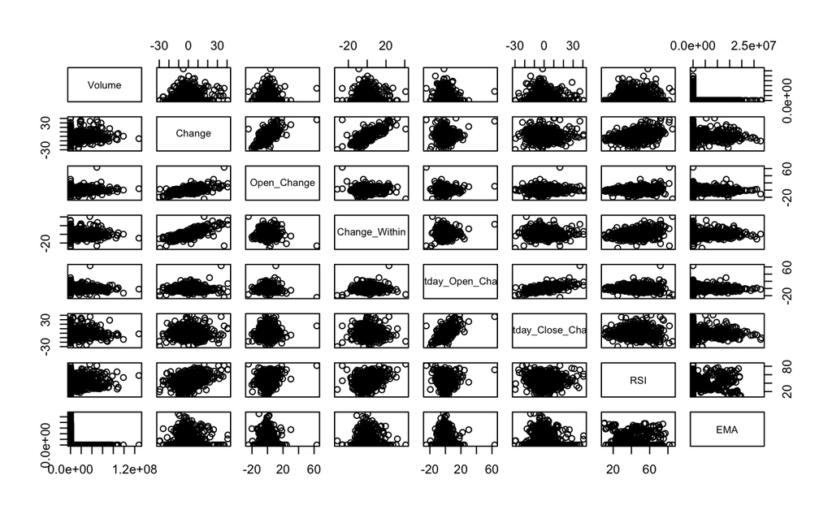

```r
pairs(df.train[c(7:14)])
```

#### 2) Scatter plot

Correlations between variables can be investigated with a scatter plot(s).

Below is a scatter plot of Change per the Next Open Change, and when the Close Price equal to High Price. We use tableau to create this scatter plot - [link](https://public.tableau.com/views/HighClose/HighClose?:embed=y&:display_count=yes)

#### 3) Several variables on the same plot

We use tableau to create some plots with several variables

Order by Volume - plot of the connection between volume to buy/sell/hold order with Nextday Change - [link](https://public.tableau.com/views/OrderbyVolumewithNextdayChange/OrderbyVolumewithNextdayClose?:embed=y&:display_count=yes&publish=yes)

Change by Order - plot of the connection between Change to buy/sell/hold Order with Nextday Change - [link](https://public.tableau.com/views/ChangebyOrderwithNextdayChange/ChangebyOrderwithNextdayChange?:embed=y&:display_count=yes&publish=yes)

Change by Open Change - plot of the connection between Change to Open Change - [link](https://public.tableau.com/views/ChangebyOpenChange/ChangebyOpenChange?:embed=y&:display_count=yes&publish=yes)

Buy when High Price touch 10 days previous max High Price - plot of Close Price with Volume/Mean Volume over time - [link](https://public.tableau.com/profile/ori.dahari#!/vizhome/AAPL_4/Dashboard1)

#### 4) Correlation

To calculate correlations we use the cor function. We create the cor table to find the relations between the variables

```r
df.num = df.train[c(2:15)]
cor_table = cor(df.num, use = "complete.obs")
View(cor_table)
```